# Chapter 5 Data analysis excercises

Silja Tammi

12/1/2023

# Chapter 5

## Exercise 1 - Graphical overview

*Move the country names to rownames. Show a graphical overview of the data and show summaries of the variables in the data. Describe and interpret the outputs, commenting on the distributions of the variables and the relationships between them.*

```r
human <- read.csv('./data/human.csv', header = T)
dim(human)
```

```
## [1] 155   9
```

```r
human <- column_to_rownames(human, "Country")
head(human)
```

```
##             Sec_edu_ratio LFPR_ratio Edu_years Life_exp   GNI Mat_mort
## Norway          1.0072389  0.8908297      17.5     81.6 64992        4
## Australia       0.9968288  0.8189415      20.2     82.4 42261        6
## Switzerland     0.9834369  0.8251001      15.8     83.0 56431        6
## Denmark         0.9886128  0.8840361      18.7     80.2 44025        5
## Netherlands     0.9690608  0.8286119      17.9     81.6 45435        6
## Germany         0.9927835  0.8072289      16.5     80.9 43919        7
##             Adol_birth_rate Rep_parl
## Norway                  7.8     39.6
## Australia              12.1     30.5
## Switzerland             1.9     28.5
## Denmark                 5.1     38.0
## Netherlands             6.2     36.9
## Germany                 3.8     36.9
```

```r
dim(human)
```

```
## [1] 155   8
```

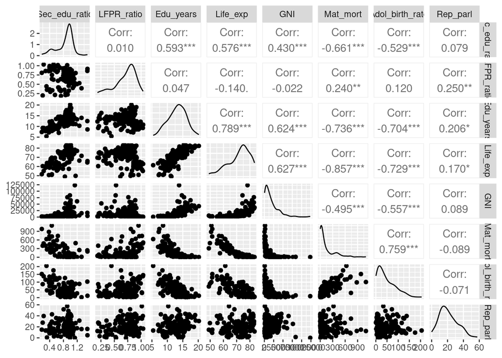

```r
ggpairs(human, progress = FALSE)
```

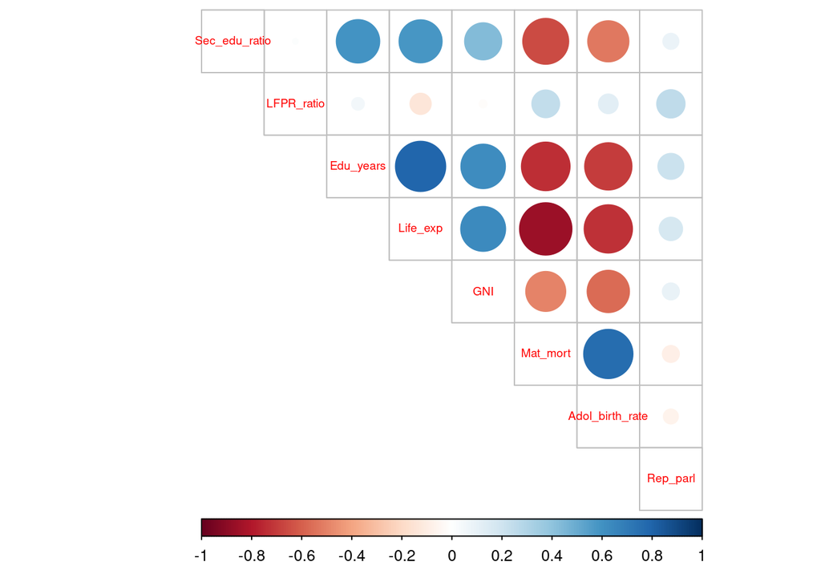

```r
cor_matrix <- cor(human) %>% round(digits=2)
corrplot(cor_matrix, method="circle", type="upper", cl.pos = "b", tl.pos = "d", tl.cex = 0.6)
```

From the ggpairs plot we can see that many variables are not normally distributed, such as `GNI` and `Mat_mort`. Many of the variables are strongly correlated. From the correlation plot we can confirm that many variables have strong positive and negative correlations, but that the variables `LFPR_ratio` and `Rep_parl` don’t seem to correlate as much with the other variables.

## Excercise 2 - PCA on non-standardized data

*Perform principal component analysis (PCA) on the raw (non-standardized) human data. Show the variability captured by the principal components. Draw a biplot displaying the observations by the first two principal components (PC1 coordinate in x-axis, PC2 coordinate in y-axis), along with arrows representing the original variables*

```r
# perform PCA on non-standardized data
pca_human <- prcomp(human)
summary(pca_human) # proportion of variance and cumulative proportion captured by the components
```

```
## Importance of components:
##                              PC1      PC2   PC3   PC4   PC5   PC6    PC7    PC8
## Standard deviation     1.854e+04 185.5219 25.19 11.45 3.766 1.566 0.1912 0.1591
## Proportion of Variance 9.999e-01   0.0001  0.00  0.00 0.000 0.000 0.0000 0.0000
## Cumulative Proportion  9.999e-01   1.0000  1.00  1.00 1.000 1.000 1.0000 1.0000
```

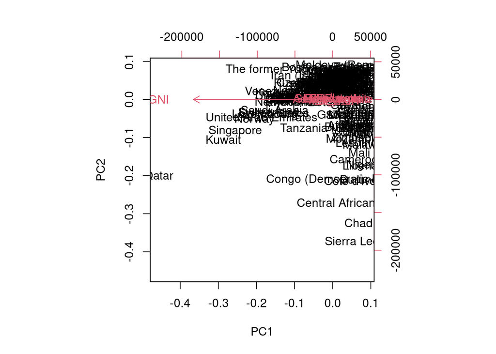

```r
# draw biplot
biplot(pca_human, choices = 1:2)
```

Since GNI has a lot wider range of values than the other variables and the data hasn’t been standardized, GNI dominates the analysis. Pretty much all the variability in the data is explained by GNI alone and the first principal component explains the majority of the variation.

## Excercise 3 - PCA on standardized data

*Standardize the variables in the human data and repeat the above analysis. Interpret the results of both analysis (with and without standardizing). Are the results different? Why or why not? Include captions (brief descriptions) in your plots where you describe the results by using not just your variable names, but the actual phenomena they relate to.*

```r
# standardize data
human_std <- scale(human)

# perform PCA on standardized data
pca_human_std <- prcomp(human_std)
summary(pca_human_std)
```

```
## Importance of components:
##                           PC1    PC2     PC3     PC4     PC5     PC6     PC7
## Standard deviation     2.0708 1.1397 0.87505 0.77886 0.66196 0.53631 0.45900
## Proportion of Variance 0.5361 0.1624 0.09571 0.07583 0.05477 0.03595 0.02634
## Cumulative Proportion  0.5361 0.6984 0.79413 0.86996 0.92473 0.96069 0.98702
##                            PC8
## Standard deviation     0.32224
## Proportion of Variance 0.01298
## Cumulative Proportion  1.00000
```

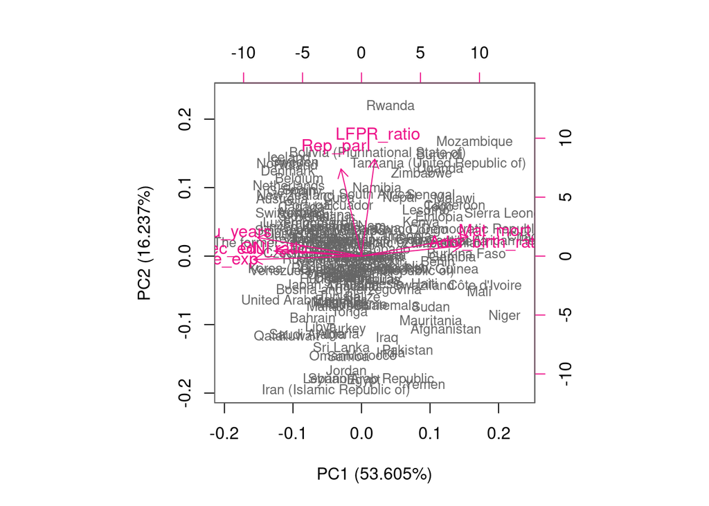

```r
# create and print out a summary of pca_human
s <- summary(pca_human_std)

# rounded percentanges of variance captured by each PC
pca_pr <- round(1*s$importance[2, ], digits = 5)

# create object pc_lab to be used as axis labels
pc_lab <- paste0(names(pca_pr), " (", pca_pr * 100, "%)")

# draw a biplot Use the first value of the `pc_lab` vector as the label for the x-axis and the second value as the label for the y-axis

biplot(pca_human_std, cex = c(0.8, 1), col = c("grey40", "deeppink2"), xlab = pc_lab[1], ylab = pc_lab[2])
```

The biplot looks different, since after scaling the data, the variables contribute equally to the analysis. The biplot is much more even now. The first principal component now explains 54% of the variation.

## Excercise 4 - Interpretations of the first two principal component dimensions

*Give your personal interpretations of the first two principal component dimensions based on the biplot drawn after PCA on the standardized human data.*

Biplot shows how strongly each characteristic influences a principal component. We can see that PC1 is is influenced by factors such as `years of education` and `life expectancy`, which are positively correlated with each other, as well as `Mat_mort`, which is negatively correlated with the other 2. PC2 is influenced by `LFPR_ratio` and `Rep_parl`, which are also positively correlated with each other.

## Excercise 5 - Visualization of Tea data

*Load the tea dataset and convert its character variables to factors. Explore the data briefly: look at the structure and the dimensions of the data. Use View(tea) to browse its contents, and visualize the data.*

```r
tea <- read.csv("https://raw.githubusercontent.com/KimmoVehkalahti/Helsinki-Open-Data-Science/master/datasets/tea.csv", stringsAsFactors = TRUE)
str(tea)
```

```
## 'data.frame':    300 obs. of  36 variables:
##  $ breakfast       : Factor w/ 2 levels "breakfast","Not.breakfast": 1 1 2 2 1 2 1 2 1 1 ...
##  $ tea.time        : Factor w/ 2 levels "Not.tea time",..: 1 1 2 1 1 1 2 2 2 1 ...
##  $ evening         : Factor w/ 2 levels "evening","Not.evening": 2 2 1 2 1 2 2 1 2 1 ...
##  $ lunch           : Factor w/ 2 levels "lunch","Not.lunch": 2 2 2 2 2 2 2 2 2 2 ...
##  $ dinner          : Factor w/ 2 levels "dinner","Not.dinner": 2 2 1 1 2 1 2 2 2 2 ...
##  $ always          : Factor w/ 2 levels "always","Not.always": 2 2 2 2 1 2 2 2 2 2 ...
##  $ home            : Factor w/ 2 levels "home","Not.home": 1 1 1 1 1 1 1 1 1 1 ...
##  $ work            : Factor w/ 2 levels "Not.work","work": 1 1 2 1 1 1 1 1 1 1 ...
##  $ tearoom         : Factor w/ 2 levels "Not.tearoom",..: 1 1 1 1 1 1 1 1 1 2 ...
##  $ friends         : Factor w/ 2 levels "friends","Not.friends": 2 2 1 2 2 2 1 2 2 2 ...
##  $ resto           : Factor w/ 2 levels "Not.resto","resto": 1 1 2 1 1 1 1 1 1 1 ...
##  $ pub             : Factor w/ 2 levels "Not.pub","pub": 1 1 1 1 1 1 1 1 1 1 ...
##  $ Tea             : Factor w/ 3 levels "black","Earl Grey",..: 1 1 2 2 2 2 2 1 2 1 ...
##  $ How             : Factor w/ 4 levels "alone","lemon",..: 1 3 1 1 1 1 1 3 3 1 ...
```

[output cut: 22 more lines]

```r
# There are no character variables, so I'm not sure what should be converted here..
summary(tea)
```

```
##          breakfast           tea.time          evening          lunch
##  breakfast    :144   Not.tea time:131   evening    :103   lunch    : 44
##  Not.breakfast:156   tea time    :169   Not.evening:197   Not.lunch:256
##
##
##
##
##
##         dinner           always          home           work
##  dinner    : 21   always    :103   home    :291   Not.work:213
##  Not.dinner:279   Not.always:197   Not.home:  9   work    : 87
##
##
##
##
##
##         tearoom           friends          resto          pub
##  Not.tearoom:242   friends    :196   Not.resto:221   Not.pub:237
##  tearoom    : 58   Not.friends:104   resto    : 79   pub    : 63
##
##
##
##
##
##         Tea         How           sugar                     how
##  black    : 74   alone:195   No.sugar:155   tea bag           :170
##  Earl Grey:193   lemon: 33   sugar   :145   tea bag+unpackaged: 94
##  green    : 33   milk : 63                  unpackaged        : 36
##                  other:  9
##
##
##
##                   where                 price          age        sex
##  chain store         :192   p_branded      : 95   Min.   :15.00   F:178
##  chain store+tea shop: 78   p_cheap        :  7   1st Qu.:23.00   M:122
##  tea shop            : 30   p_private label: 21   Median :32.00
##                             p_unknown      : 12   Mean   :37.05
##                             p_upscale      : 53   3rd Qu.:48.00
##                             p_variable     :112   Max.   :90.00
##
```

[output cut: 25 more lines]

```
##  feminine    :129   Not.sophisticated: 85   No.slimming:255   exciting   :116
##  Not.feminine:171   sophisticated    :215   slimming   : 45   No.exciting:184
##
##
##
##
##
##         relaxing              effect.on.health
##  No.relaxing:113   effect on health   : 66
##  relaxing   :187   No.effect on health:234
##
##
##
##
##
```

```r
# make a smaller data set of 'tea'
keep_columns <- c("breakfast", "evening", "work", "Tea", "sugar", "sex", "Sport", "relaxing", "effect.on.health")

# select the 'keep_columns' to create a new dataset
tea_time <- dplyr::select(tea, keep_columns)
```

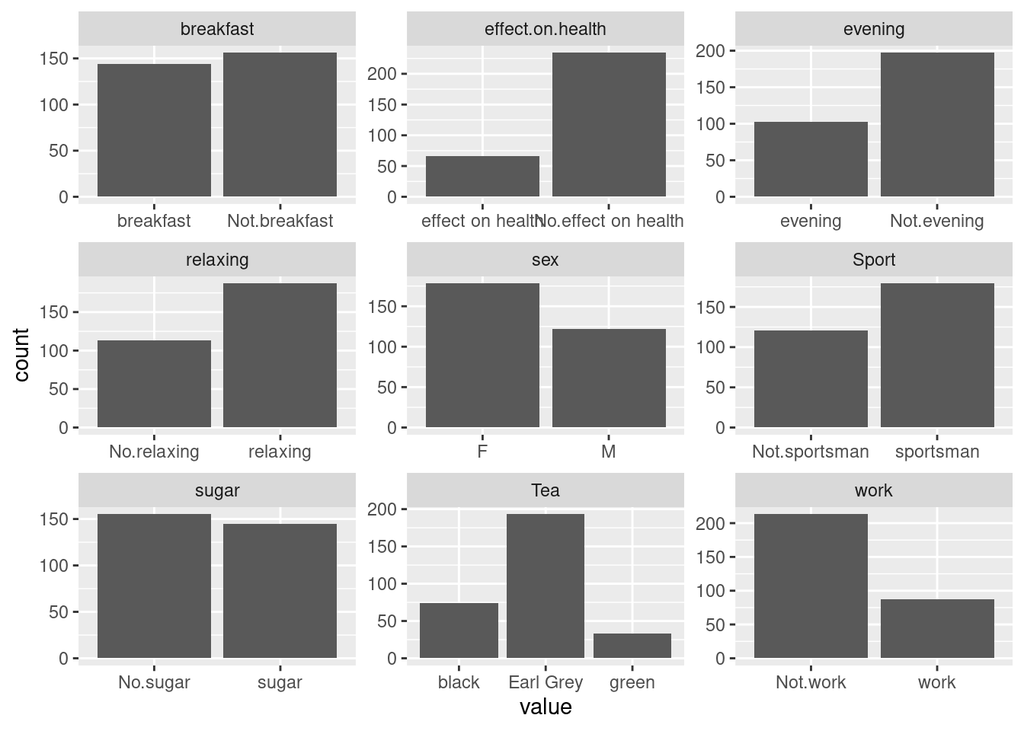

```r
# ggplot
pivot_longer(tea_time, cols = everything()) %>%
  ggplot(aes(value)) + facet_wrap("name", scales = "free") + geom_bar()
```

## Exercise 5 - Multiple Correspondence Analysis (MCA)

*Use Multiple Correspondence Analysis (MCA) on the tea data (or on just certain columns of the data, it is up to you!). Interpret the results of the MCA and draw at least the variable biplot of the analysis. You can also explore other plotting options for MCA. Comment on the output of the plots.*

```r
# multiple correspondence analysis
mca <- MCA(tea_time, graph = FALSE)

# summary of the model
summary(mca)
```

```
##
## Call:
## MCA(X = tea_time, graph = FALSE)
##
##
## Eigenvalues
##                        Dim.1   Dim.2   Dim.3   Dim.4   Dim.5   Dim.6   Dim.7
## Variance               0.162   0.145   0.134   0.132   0.119   0.102   0.091
## % of var.             14.570  13.059  12.047  11.859  10.720   9.215   8.149
## Cumulative % of var.  14.570  27.629  39.676  51.534  62.254  71.470  79.619
##                        Dim.8   Dim.9  Dim.10
## Variance               0.083   0.078   0.066
## % of var.              7.453   7.008   5.919
## Cumulative % of var.  87.072  94.081 100.000
##
## Individuals (the 10 first)
##                  Dim.1    ctr   cos2    Dim.2    ctr   cos2    Dim.3    ctr
## 1             |  0.007  0.000  0.000 |  0.199  0.091  0.035 |  0.407  0.412
## 2             |  0.500  0.515  0.242 | -0.187  0.080  0.034 |  0.595  0.880
## 3             | -0.303  0.190  0.092 | -0.444  0.452  0.196 | -0.082  0.017
## 4             | -0.230  0.109  0.065 |  0.383  0.337  0.181 | -0.314  0.246
## 5             | -0.503  0.522  0.288 | -0.009  0.000  0.000 |  0.387  0.373
## 6             | -0.115  0.027  0.019 |  0.192  0.085  0.052 |  0.071  0.013
## 7             | -0.154  0.049  0.033 | -0.086  0.017  0.010 |  0.324  0.262
## 8             | -0.160  0.053  0.024 |  0.142  0.046  0.019 |  0.593  0.877
## 9             | -0.154  0.049  0.033 | -0.086  0.017  0.010 |  0.324  0.262
## 10            | -0.179  0.066  0.026 |  0.205  0.096  0.034 |  0.849  1.796
##                 cos2
## 1              0.146 |
## 2              0.342 |
## 3              0.007 |
## 4              0.122 |
## 5              0.170 |
## 6              0.007 |
## 7              0.145 |
## 8              0.334 |
## 9              0.145 |
## 10             0.578 |
##
## Categories (the 10 first)
```

[output cut: 19 more lines]

```
## Earl Grey      -7.385 |  -0.494  13.026   0.440 -11.469 |
## green           9.062 |  -0.136   0.169   0.002  -0.826 |
## No.sugar       -3.498 |   0.458   8.987   0.224   8.184 |
##
## Categorical variables (eta2)
##                    Dim.1 Dim.2 Dim.3
## breakfast        | 0.005 0.226 0.174 |
## evening          | 0.360 0.016 0.010 |
## work             | 0.001 0.478 0.030 |
## Tea              | 0.121 0.316 0.608 |
## sugar            | 0.324 0.041 0.224 |
## sex              | 0.101 0.204 0.026 |
## Sport            | 0.126 0.015 0.025 |
## relaxing         | 0.379 0.002 0.091 |
## effect.on.health | 0.041 0.008 0.018 |
```

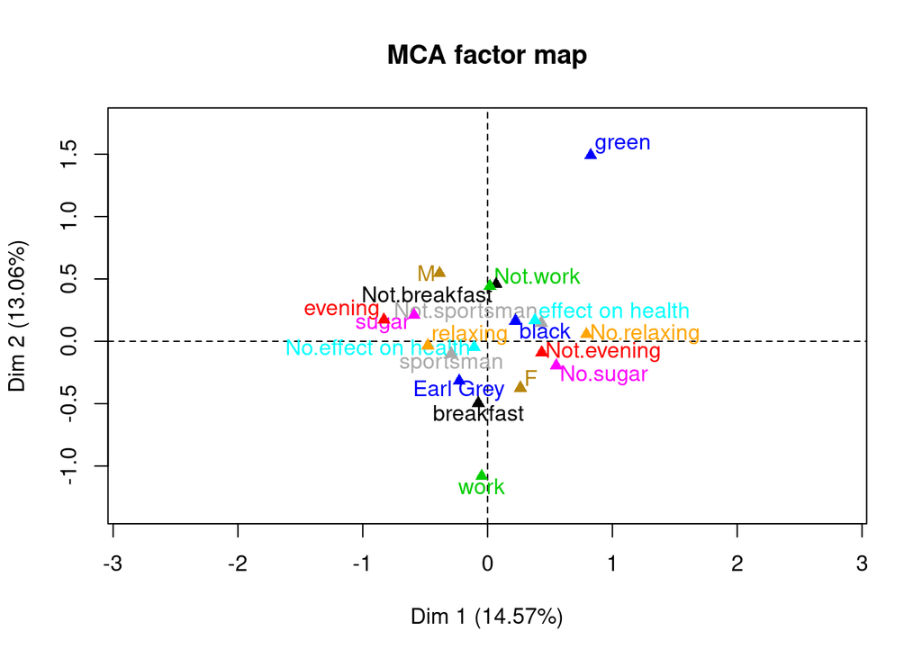

```r
# visualize the model
plot(mca, invisible=c("ind"), graph.type = "classic", habillage = "quali")
```

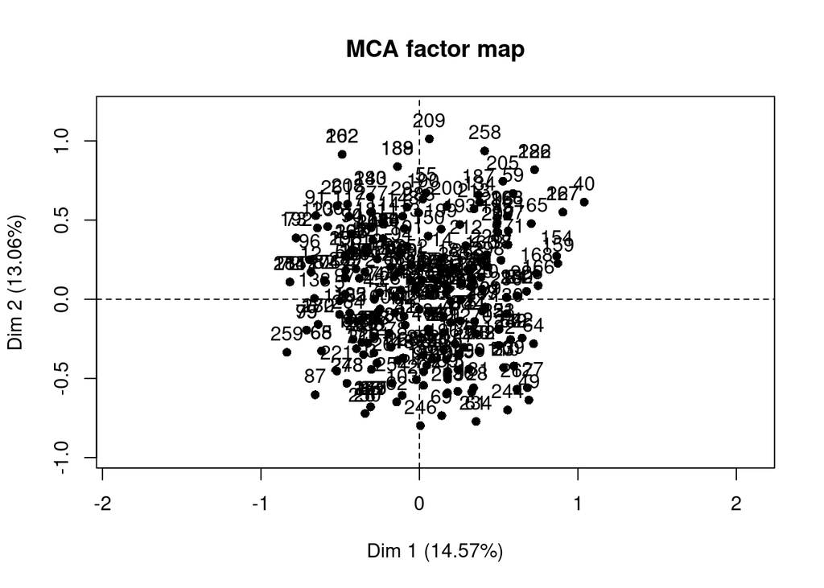

```r
plot(mca, invisible=c("var"), graph.type = "classic", habillage = "quali")
```

The distance between variables gives a measure of their similarity (or dissimilarity). For example `Relaxing` and `evening` seem to contribute most to Dim 1, whereas variables `work` and `Tea` contribute greatly to Dim2.

From the individuals’ scatterplot we can see that there is no particular group of individuals, the scatterplot is quite homogeneous.